# Recognizing Correctness of Exercise Movement.

WE Hopkins

March 21, 2016

# Summary

The research question is whether proper form during exercise can be determined from personal sensor data. In this particular work, it is about form during a unilateral bicep curl with a dumbbell. The training data from a [previous study](http://groupware.les.inf.puc-rio.br/public/papers/2013.Velloso.QAR-WLE.pdf) was provided along with instructions to use any of the provided variables and a set of test data from which to determine whether the associated movement followed one of the classes of form (identified by the classe variable as A, B, C, D, or E).

A number of models performed very well (rpart, ctree, knn), but random forest (rf) did the best with a median accuracy of 99.9% on 10-fold cross validation. This result, however, is not likely to generalize well since the variable most important (by 100.0 vs. 50.8 for the next most important) was raw_timestamp_part_1.

# Preliminary Feature Selection

The test data set provided for the project defines what is available for the basis of making predictions even though the training data set had all the same variables. It consists of 20 rows of observations, made up of 159 variables (or features). Of those 159 variables, 100 had no values (equal to “NA”), effectively making those variables unavailable for use in the models (it turns out that they were all the “summary” variables - statistics based on time windows of the actual sensor measurements).

Thus, the original data sets were immediately reduced from 159 variables to 59. Incidentally, many of those eliminated variables had bad values in the training data set; being able to eliminate them greatly reduced the amount of data cleaning needed.

# Preprocessing

Many of the machine learning models are sensitive to various characteristics of the predictor variables.

## Near Zero Variance

There are those models that need to avoid variables with near zero variance (nzv). Caret provides a function, nearZeroVar(), which identifies them. In the training data set, new_window is a near zero variance variable.

For all the observations for user_name==“adelmo”, the values of roll_forearm, pitch_forearm, and yaw_forearm were set to zero, making them nzv in the context of that user, but in the context of the rest of the users, it wasn’t a problem and could be useful given the test data set.

Similarly for user_name==“jeremy” and roll_arm, yaw_arm, and pitch_arm.

## Collinearity

The other main problem for some variables is collinearity. Caret provides the function, findCorrelation(), to locate variables to leave out when collinearity is an issue. In the training data, it is the following variables: accel_belt_z, roll_belt, accel_belt_y, accel_belt_x, gyros_arm_y, gyros_forearm_z, gyros_dumbbell_x. Here is a plot (using corrplot::corrplot()) providing a quick view of groupings of collinear variables.

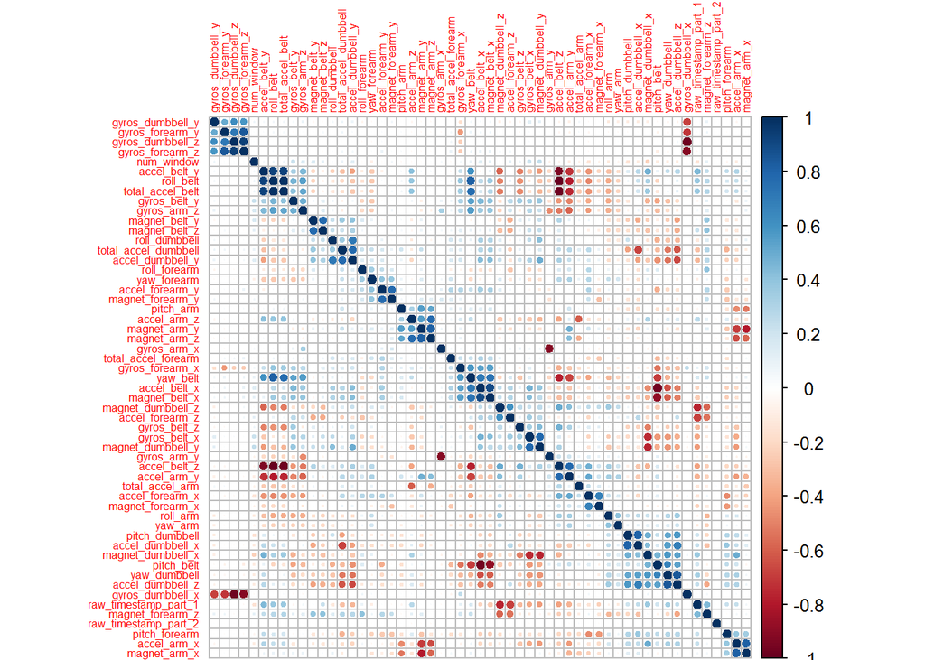

# Model Strategy

Each model was trained using 10-fold cross validation. To facilitate pair-wise statistical comparisons via resample(), the same random seed is set prior to training each model.

Initially, models were built using a subset of the training data so as to more quickly determine issues with the data or the model parameters.

Also, on a per-model basis, values for tunable model parameters were adjusted. Each model was originally run with the default set of tunable parameter values, then the values were explicity set using the train() function’s tuneGrid parameter to move the range to where accuracy is maximized.

Here is the output creating the rpart model:

```
CART

19622 samples
   58 predictor
    5 classes: 'A', 'B', 'C', 'D', 'E'

No pre-processing
Resampling: Cross-Validated (10 fold)

Summary of sample sizes: 17659, 17659, 17659, 17660, 17660, 17659, ...

Resampling results across tuning parameters:

  cp       Accuracy      Kappa         Accuracy SD     Kappa SD
  0.00002  0.9891444826  0.9862682205  0.002055376747  0.002601176105
  0.00004  0.9891954250  0.9863326391  0.002148152860  0.002718545823
  0.00006  0.9891444306  0.9862680775  0.002151677062  0.002723023461
  0.00008  0.9890426237  0.9861389007  0.002139941417  0.002707985717
  0.00010  0.9890426237  0.9861389007  0.002139941417  0.002707985717
  0.00012  0.9889916813  0.9860744701  0.002192397347  0.002774305869
  0.00014  0.9890426497  0.9861388583  0.002193033433  0.002775096784
  0.00016  0.9891446385  0.9862676668  0.002068105039  0.002616853080
  0.00018  0.9890427536  0.9861391088  0.002139133859  0.002706218784
  0.00020  0.9887879375  0.9858168076  0.002228377067  0.002819245381

Accuracy was used to select the optimal model using  the largest value.
The final value used for the model was cp = 4e-05.
```

Note that each model provides the standard deviation for the performance metrics, based on the results of running, in this case, 10 fold cross-validation.

Caret overrides the plot() function to provide a graph of the accuracy vs. tunable parameter value:

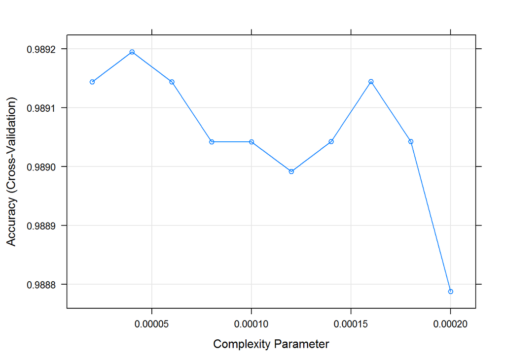

Some model parameters are not tunable in the sense that multiple values are evaluated via cross-validation, but can determine important model behavior. For example, random forest (rf) take a notoriously long time to run on most PCs (it does have an option to run in parallel, but not on Windows). In this case, I tried a much reduced value for the number of trees to build: 50 instead of the default 500. It made it feasible to run and provided the best accuracy of all the models (median accuracy was 99.9% during cross validation).

Some of the models provide model-specific diagnostics. Naive Bayes provides diagnostic plots in the form of conditional densities by classifier value. The plot for raw_timestamp_part_1 was very instructive in showing that the training data uniquely identifies the classe given raw_timestamp_part_1; the chart below shows the density plots for each user_name value with the test data timestamp values indicated by the verticle black lines:

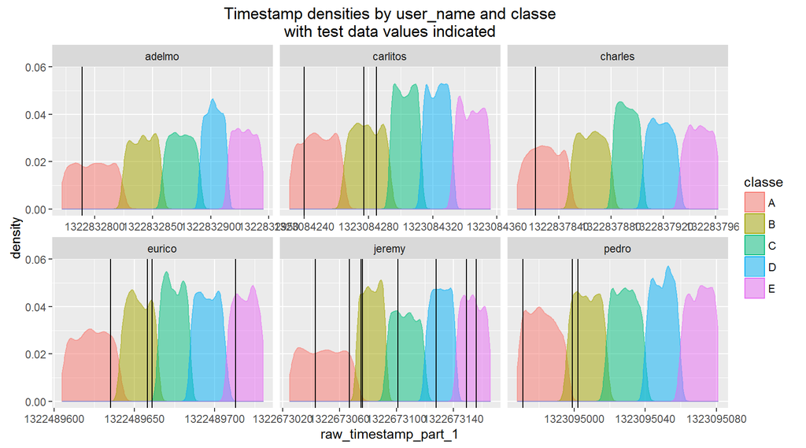

Non-linear models such as those based on trees (rpart, ctree, random forest) or on conditional probabilities (naive bayes) are capable of leveraging the relationship between raw_timestamp_part_1 and classe.

## Model Selection

Caret provides functions that can use paired statistical tests on the model outputs to determine which models performed differently at statistically significant levels.

The primary function for this, caret::resample(), takes a list of models generated by caret::train() and uses the results of the resampling to derive statistics on accuracy and Kappa (for classification). If the same resampling approach is used for all the training (10-fold cross-validation in this case), then paired tests are used to determine, for the evaluation of each pair of models, the level of statisical significance (via a p-value).

```
Call:
summary.resamples(object = resamp)

Models: PenalizedLDA, pls, rpart, lda, knn, rf, nb
Number of resamples: 10

Accuracy
              Min. 1st Qu. Median  Mean 3rd Qu.  Max. NA's
PenalizedLDA 0.645   0.661  0.664 0.667   0.674 0.688    0
pls          0.841   0.845  0.847 0.848   0.850 0.858    0
rpart        0.986   0.988  0.989 0.989   0.991 0.993    0
lda          0.812   0.820  0.824 0.825   0.828 0.841    0
knn          0.994   0.996  0.997 0.997   0.997 0.998    0
rf           0.998   0.999  0.999 0.999   1.000 1.000    0
nb           0.699   0.714  0.724 0.727   0.731 0.793    0

Kappa
              Min. 1st Qu. Median  Mean 3rd Qu.  Max. NA's
PenalizedLDA 0.554   0.574  0.578 0.581   0.591 0.606    0
pls          0.798   0.803  0.806 0.807   0.810 0.820    0
rpart        0.983   0.985  0.986 0.986   0.988 0.991    0
lda          0.763   0.773  0.777 0.779   0.783 0.799    0
knn          0.993   0.995  0.996 0.996   0.997 0.997    0
rf           0.997   0.999  0.999 0.999   1.000 1.000    0
nb           0.608   0.627  0.641 0.646   0.650 0.735    0
```

Here is table showing the difference in performance metric values and the p-value of the pairwise comparison of model performance (the null hypothesis is no difference).

```
Call:
summary.diff.resamples(object = modelDifferences)

p-value adjustment: bonferroni
Upper diagonal: estimates of the difference
Lower diagonal: p-value for H0: difference = 0

Accuracy
             PenalizedLDA pls      rpart    lda      knn      rf       nb
PenalizedLDA              -0.18087 -0.32239 -0.15814 -0.32983 -0.33248 -0.06045
pls          2.66e-11              -0.14152  0.02273 -0.14897 -0.15162  0.12042
rpart        3.60e-13     2.41e-12           0.16425 -0.00744 -0.01009  0.26195
lda          1.51e-10     1.42e-05 2.78e-11          -0.17169 -0.17434  0.09769
knn          3.22e-13     2.50e-13 2.43e-05 6.60e-12          -0.00265  0.26939
rf           2.15e-13     1.28e-13 4.09e-06 3.24e-12 4.56e-05           0.27204
nb           0.00135      2.53e-06 5.21e-09 1.17e-05 2.80e-09 2.33e-09

Kappa
             PenalizedLDA pls      rpart    lda      knn      rf       nb
PenalizedLDA              -0.22616 -0.40540 -0.19782 -0.41481 -0.41816 -0.06475
pls          2.51e-11              -0.17923  0.02834 -0.18865 -0.19200  0.16141
rpart        3.21e-13     2.59e-12           0.20757 -0.00941 -0.01276  0.34064
lda          1.39e-10     1.56e-05 2.87e-11          -0.21698 -0.22034  0.13307
knn          2.83e-13     2.72e-13 2.43e-05 6.73e-12          -0.00335  0.35006
rf           1.87e-13     1.41e-13 4.10e-06 3.32e-12 4.58e-05           0.35341
nb           0.00742      2.87e-06 7.52e-09 1.17e-05 4.18e-09 3.51e-09
```

Random forest (rf) does perform best, and is statistically different from the others.

# Predictions

Here are the predictions for the provided test data using the most accurate model, random forest (rf):

```
 rownum prediction
      1          B
      2          A
      3          B
      4          A
      5          A
      6          E
      7          D
      8          B
      9          A
     10          A
     11          B
     12          C
     13          B
     14          A
     15          E
     16          E
     17          A
     18          B
     19          B
     20          B
```

# Further Research

Other directions of research to continue from this include:

- Eliminate the use of variables, such as raw_timestamp_part_1, that are specific to a particular instance of performing the movement. Some of the models did well without relying on raw_timestamp_part_1 (but the best performing models did rely on it).
- Predict from data collected separately from those used for training. It is clear that the testing set provided was sampled from the training set.